# (US air force on-time and delayed flights analysis)

## by (Mahmoud Samneh)

## Investigation Overview

> Through this analysis we will highlight and study the flights movment through each airport from the 2017 till 2020 we will be exposed to each factor that influnces the flights movment.

> we will focus on many aspects to analyse the dataset and to extract insights that will help us improve the flight's movement through this project we will focus on the below study cases.

> Case study 1: what is the portion of canceled and diverted of top ten airports? Case study 2: Through 2017 till 2020 are delayed flights increase or decrease? Case study 3: For each airport what is the delaying factor for the flights? Case study 4: For the airports with the highest value of delayed flights what is the cause that contributed the most ?

## Dataset Overview

Case study 1: what is the portion of canceled and diverted of top ten airports?

> By answering this question we will demonstrate the percentage of cancelled and diverted flights the percentages yields the performance of the airport in general and it shows how each airport stand to each other

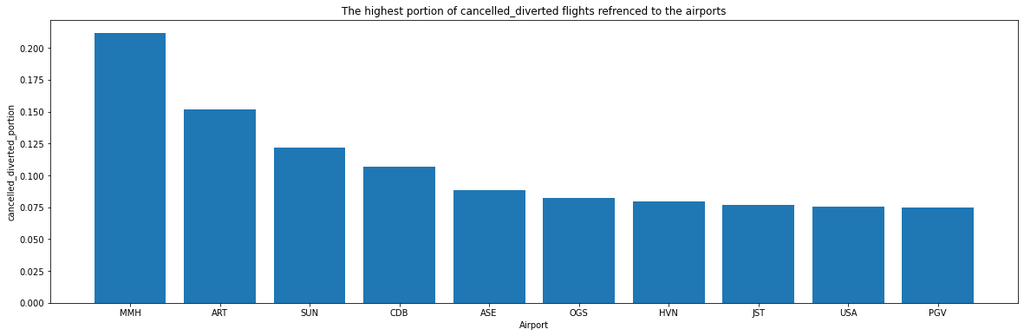

From the previous bar chart we found the airports that has the highest not arrival flights which will make the passengers think twice when they see these names once they book there flights , a bad trend for revenue which needs to do gap analysis

Case study 2: Through 2017 till 2020 are delayed flights increase or decrease?

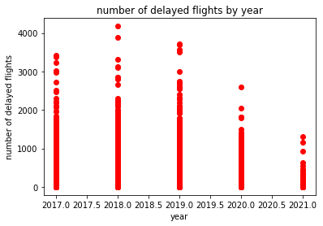

Case study 3: For each airport what is the delaying factor for the flights?

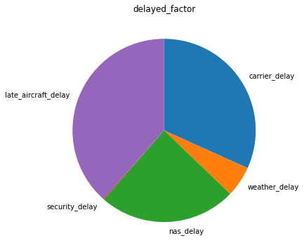

Through this pie chart we found that late_aircraft and carrier are the most affective factors for delaying the flights we need to dig deep to reduce this delay

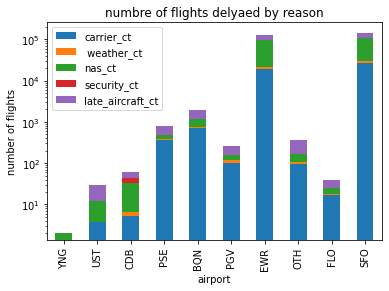